# Interpretation ivB

Keyon Hedayati

4/25/2022

```r
library(tidyverse)
library(caret)
library(ggpointdensity)
library(yardstick)
```

Load the entire dataset

```r
df_all <- readr::read_csv("final_project_train.csv", col_names = TRUE)
```

Load up the best performing regression and classification models. However, for regression, I will load the 3rd best.

**Regression**

```r
re_glmnet_cont_pairs_cat_add <- readr::read_rds('glmnet_cont_pairs_cat_add.rds')
```

Will pull out the best tuned results

```r
glmnet_pred_results <- re_glmnet_cont_pairs_cat_add$pred %>% tibble::as_tibble() %>%
              filter(alpha == re_glmnet_cont_pairs_cat_add$bestTune$alpha,
                     lambda == re_glmnet_cont_pairs_cat_add$bestTune$lambda) %>%
              select(pred, obs, rowIndex, Resample) %>%
              mutate(model_name = "GLMNET")

glmnet_pred_results
```

```
## # A tibble: 2,031 × 5
##     pred    obs rowIndex Resample    model_name
##    <dbl>  <dbl>    <int> <chr>       <chr>
##  1 1.46  1.00          4 Fold01.Rep1 GLMNET
##  2 0.895 1.04         28 Fold01.Rep1 GLMNET
##  3 1.42  1.72         35 Fold01.Rep1 GLMNET
##  4 0.977 1.19         77 Fold01.Rep1 GLMNET
##  5 0.844 1.05         81 Fold01.Rep1 GLMNET
##  6 1.09  1.17         82 Fold01.Rep1 GLMNET
##  7 0.328 0.429        96 Fold01.Rep1 GLMNET
##  8 0.675 0.432        98 Fold01.Rep1 GLMNET
##  9 0.330 0.0567      104 Fold01.Rep1 GLMNET
## 10 0.910 0.896       112 Fold01.Rep1 GLMNET
## # … with 2,021 more rows
```

Now we will connect them to the actual inputs to see how they performed.

```r
df_new <- df_all %>%
  mutate(y = log(response), rowIndex = rowid) %>%
  select(region, customer, starts_with('x'), y, rowIndex)
```

Merge the predictions with the original dataframe

```r
pred_df <- merge(df_new, glmnet_pred_results, by= "rowIndex")
pred_df %>% head()
```

```
##   rowIndex region customer xb_01 xb_02 xb_03 xn_01 xn_02 xn_03 xa_01 xa_02
## 1        1     XX        B     4     4     4     3     3     3    12    12
## 2        1     XX        B     4     4     4     3     3     3    12    12
## 3        1     XX        B     4     4     4     3     3     3    12    12
## 4        3     XX        B     1     1     1     2     2     2     3     3
## 5        3     XX        B     1     1     1     2     2     2     3     3
## 6        3     XX        B     1     1     1     2     2     2     3     3
##   xa_03    xb_04    xb_05    xb_06 xb_07 xb_08 xn_04 xn_05 xn_06 xn_07 xn_08
## 1    12 1.333333 1.333333 1.333333     4    -1     1     1     1     3    -1
## 2    12 1.333333 1.333333 1.333333     4    -1     1     1     1     3    -1
## 3    12 1.333333 1.333333 1.333333     4    -1     1     1     1     3    -1
## 4     3 1.000000 1.000000 1.000000     1     1     2     2     2     2     2
## 5     3 1.000000 1.000000 1.000000     1     1     2     2     2     2     2
## 6     3 1.000000 1.000000 1.000000     1     1     2     2     2     2     2
##   xa_04 xa_05 xa_06 xa_07 xa_08 xw_01 xw_02 xw_03     xs_01     xs_02     xs_03
```

[output cut: 20 more lines]

Lets see how the predictions look compared to the observations

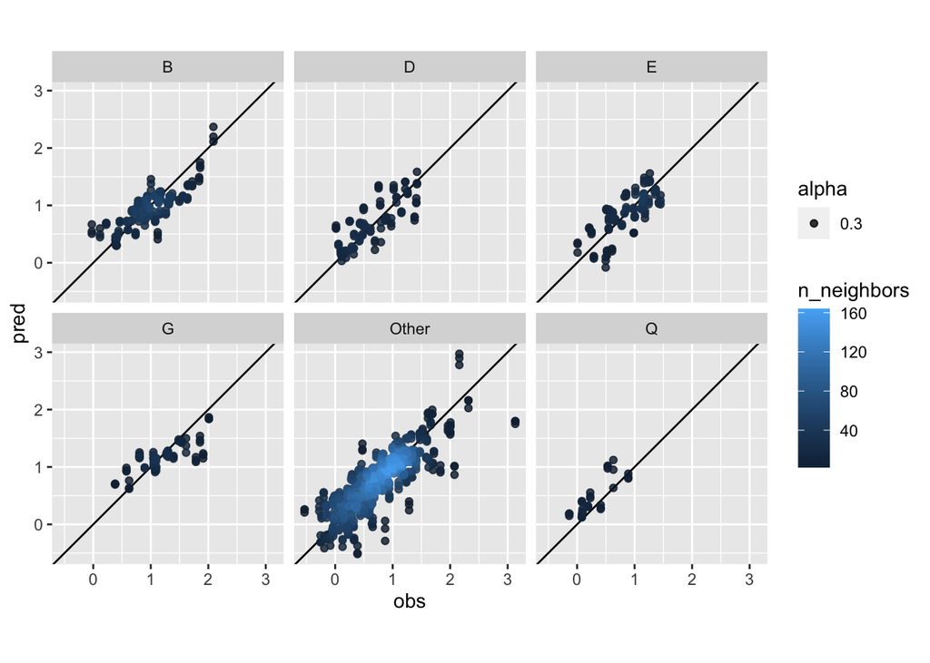

```r
pred_df %>% ggplot(mapping = aes(x=obs, y=pred, alpha=0.3)) +
  geom_point() +
  coord_equal()+
  geom_abline(slope = 1)+
  facet_wrap(~customer) +
  geom_pointdensity()
```

Maybe it is an obvious guess, but by looking at the data **Other** appears to be the hardest to predict with the most ‘noise’ around the line.

**Classification**

Now lets try the same thing with the best classification model. Remember, many of them were similar, we just pulled the top of the chart. The tuned version had a narrower confidence interval though.

```r
re_model_avg_nnet <- readr::read_rds('model_avg_nnet_class.rds')
```

Lest see the best tuning parameters

```r
re_model_avg_nnet$bestTune
```

```
##   size decay   bag
## 3    1   0.1 FALSE
```

```r
re_model_avg_nnet$pred %>% head()
```

```
##        pred       obs event non_event rowIndex size decay   bag Resample
## 1 non_event non_event     0         1        2    1     0 FALSE    Fold1
## 2 non_event non_event     0         1        4    1     0 FALSE    Fold1
## 3 non_event non_event     0         1        7    1     0 FALSE    Fold1
## 4 non_event non_event     0         1        9    1     0 FALSE    Fold1
## 5 non_event non_event     0         1       41    1     0 FALSE    Fold1
## 6 non_event non_event     0         1       49    1     0 FALSE    Fold1
```

Now we pull out the predictions with best tune

```r
avg_nnet_pred_results <- re_model_avg_nnet$pred %>% tibble::as_tibble() %>%
              filter(size == re_model_avg_nnet$bestTune$size,
                     decay == re_model_avg_nnet$bestTune$decay,
                     bag == re_model_avg_nnet$bestTune$bag) %>%
              select(pred, obs,event, non_event, rowIndex, Resample) %>%
              mutate(model_name = "AVG_NNET")

avg_nnet_pred_results
```

```
## # A tibble: 677 × 7
##    pred      obs        event non_event rowIndex Resample model_name
##    <fct>     <fct>      <dbl>     <dbl>    <int> <chr>    <chr>
##  1 non_event non_event 0.0467     0.953        2 Fold1    AVG_NNET
##  2 non_event non_event 0.0504     0.950        4 Fold1    AVG_NNET
##  3 non_event non_event 0.341      0.659        7 Fold1    AVG_NNET
##  4 non_event non_event 0.221      0.779        9 Fold1    AVG_NNET
##  5 non_event non_event 0.0759     0.924       41 Fold1    AVG_NNET
##  6 event     non_event 0.732      0.268       49 Fold1    AVG_NNET
##  7 non_event non_event 0.0456     0.954       54 Fold1    AVG_NNET
##  8 non_event non_event 0.0521     0.948       60 Fold1    AVG_NNET
##  9 non_event non_event 0.0446     0.955       73 Fold1    AVG_NNET
## 10 non_event non_event 0.0507     0.949       78 Fold1    AVG_NNET
## # … with 667 more rows
```

Now we merge them like we did before

```r
pred_class_df <- merge(df_new, avg_nnet_pred_results, by= "rowIndex")
pred_class_df %>% head()
```

```
##   rowIndex region customer    xb_01 xb_02 xb_03     xn_01 xn_02 xn_03     xa_01
## 1        1     XX        B 4.000000     4     4 3.0000000     3     3 12.000000
## 2        3     XX        B 1.000000     1     1 2.0000000     2     2  3.000000
## 3        4     XX        B 2.000000     2     2 2.0000000     4     0  9.000000
## 4        5     XX        B 2.520000    11    -6 1.5333333     9    -3  7.080000
## 5        8     XX        B 2.548387     6    -1 0.8387097     3    -4  6.451613
## 6        9     XX        B 3.071429     6     1 1.8571429     8    -2  6.857143
##   xa_02 xa_03     xb_04     xb_05    xb_06    xb_07      xb_08     xn_04
## 1    12    12 1.3333333  1.333333 1.333333 4.000000 -1.0000000 1.0000000
## 2     3     3 1.0000000  1.000000 1.000000 1.000000  1.0000000 2.0000000
## 3     9     9 1.0000000  1.000000 1.000000 2.000000  0.0000000 1.0000000
## 4    29    -7 0.8950476 -2.000000 4.000000 1.933333 -0.0800000 0.5268889
## 5    17    -2 1.2247312 -0.500000 4.000000 1.967742  0.3548387 0.4688172
## 6    18     2 1.1857143  0.000000 3.000000 1.714286  0.5000000 0.5607143
##       xn_05 xn_06    xn_07      xn_08    xa_04      xa_05 xa_06    xa_07
```

[output cut: 27 more lines]

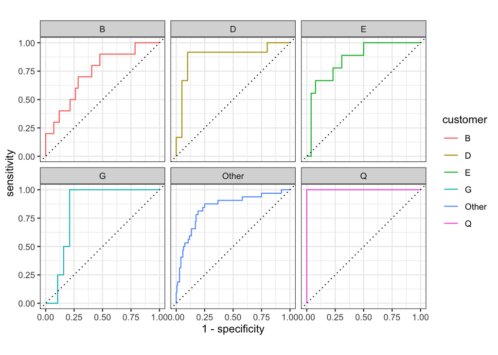

```r
pred_class_df %>%
  group_by(customer) %>%
  roc_curve(obs, event) %>%
  ggplot(mapping = aes(x = 1 - specificity, y = sensitivity)) +
  geom_path(mapping = aes(color = customer)) +
  geom_abline(slope = 1, intercept = 0, linetype = 'dotted') +
  coord_equal() +
  facet_wrap(~customer) +
  theme_bw()
```

This gives a slightly different picture than the regression model. According to this, **customer B** is hardest to predict, and **Other** is maybe second place.